# Bayes & Coin Fairness

### **NOTES ON STATISTICS, PROBABILITY and MATHEMATICS**

### Bayes’ Approach Coin Fairness:

I’d like to post some illustrations about the way our preconceptions about the “fairness” of the coin (or the experiment in general) affects the *posterior probability density*, i.e. the $p\,(\theta\,|\,\text{Data})$, where $\theta$ stands for the probability of ending up with $\text{heads}$ in the coin toss.

Luckily, we have a [conjugate prior distribution](https://en.wikipedia.org/wiki/Conjugate_prior) for the binomial case that occupies us - the $\text{beta}$ distribution, facilitating the calculation of the posterior distribution.

A *prior* is *conjugate* to the *likelihood* when the *posterior* is in the same family of distributions as the *prior*: $\text{posterior}\, \Pr(\theta|y) \propto \,\text{likelihood}\,\Pr(y|\theta)\,\times\,\text{prior}\,\Pr(\theta)$. $y$ stands for the data observed; $\theta$ is the parameter we want to estimate. The *binomial-beta* is a conjugate model. Let’s call the probability of the binomial $\theta$:

$$\begin{align}
p(\theta|y) \propto p(y|\theta)\,p(\theta)
&=\text{Bin}(n,\theta) \times \text{Beta}(a,b)\\[2ex]
&={n\choose
y}\,\theta^y\,(1\,-\,theta)^{(n-y)}\,\times\,\frac{\Gamma(a+b)}{
\Gamma(a)\Gamma(b)}\,\theta^{(a-1)}\,(1-\theta)^{b-1}
\propto \theta^y\,(1-\theta)^{(n-y)}\theta^{a-1}(1-\theta)^{b-1}\\[2ex]
&=p(\theta|y) \propto \theta^{(y+a-1)}\,(1\,-\,\theta)^{(n-y+b-1)}
\end{align}$$

Hence, the posterior distribution is a $\text{Beta}\,(y+a,\,n-y+b)$.

```
First scenario - The Fair-Minded Player:
```

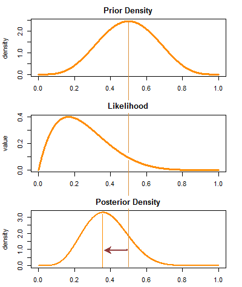

```
Second Scenario - The Shrewd Player:
```

We strongly suspect from insider’s leaked information that the game is markedly biased towards tails, and we not only are about to make a killing, but also in need to further reinforce our conviction after the first round, doubling down our bet:

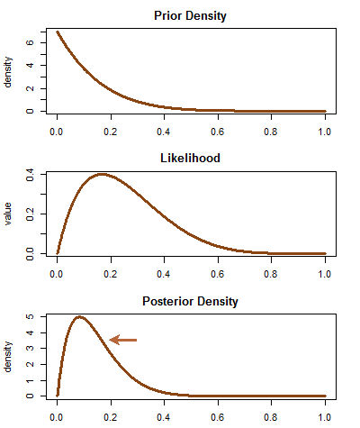

```
Third Scenario - Losing Your Shirt:
```

We’ve never played before, but we have read a manual, and we feel ready. All signs clearly indicate that the coin is markedly biased towards $\text{heads}$, a mistake that we will soon start to correct at a high $\$$ cost:

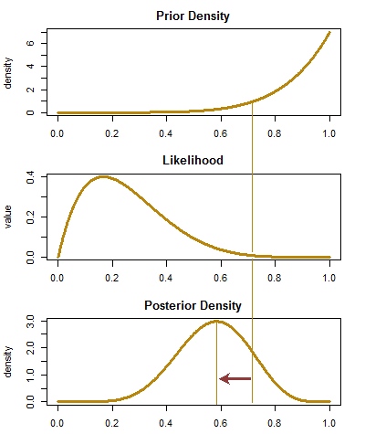

```
Fourth Scenario - No Idea Whatsoever:
```

It’s a good thing that the $\text{Beta}(1,1)$ distribution turns into a $\text{Unif}\,(0,1)$ to address this scenario, where only the $\text{likelihood}$ will influence the $\text{posterior}$ probability of $\theta$. As brought up to my attention, a [Jeffreys prior is close and possibly more correct](https://tamino.wordpress.com/2010/11/25/prior-knowledge/):

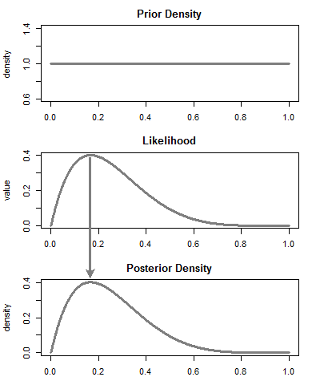

So I hope this provides a bit of a light-hearted visual depiction of our approach to estimating the chances of this game being rigged, perhaps encapsulating more of a real scenario than calculations of the type `pbinom(1, 6, 0.5)`. If you want the code in R, and the credits to a great video with Matlab illustrations, [I posted it here](https://github.com/RInterested/SIMULATIONS_and_PROOFS/blob/master/BAYES%20FAIR%20COIN).

[Home Page](http://rinterested.github.io/statistics/index.html)

**NOTE: These are tentative notes on different topics for personal use - expect mistakes and misunderstandings.**